# SW138V288_G139001

```python
# !pip install pmdarima
```

```python
# Import Libraries
import numpy as np
import pandas as pd
import matplotlib.pyplot as plt
import seaborn as sns
from sklearn.preprocessing import StandardScaler

from pmdarima import auto_arima
from statsmodels.tsa.arima.model import ARIMA
from sklearn.linear_model import LinearRegression
from sklearn.ensemble import RandomForestRegressor
from sklearn.svm import SVR
from xgboost import XGBRegressor

from sklearn.metrics import mean_squared_error, mean_absolute_error, r2_score
from sklearn.model_selection import train_test_split

import warnings
warnings.filterwarnings("ignore")
```

## 1. Load & Understand Dataset

```python
# Load the dataset
df = pd.read_excel("Export+05_03_2025+01_36.xlsx", sheet_name="HSBC_HOLDINGS_PLC")

# Disply first five records
df.head()
```

|  | Date | Open (£) | High (£) | Low (£) | Close (£) | Volume (shares) | Shares outstanding | Market cap (m £) |
| --- | --- | --- | --- | --- | --- | --- | --- | --- |
| 0 | 2010-05-28 | 6.385 | 6.400 | 6.270 | 6.278 | 35776668 | 17509647048 | 109925.562030 |
| 1 | 2010-06-01 | 6.222 | 6.355 | 6.222 | 6.355 | 50609420 | 17509647048 | 111273.807324 |
| 2 | 2010-06-02 | 6.260 | 6.339 | 6.220 | 6.338 | 23121252 | 17509647048 | 110976.139851 |
| 3 | 2010-06-03 | 6.370 | 6.449 | 6.348 | 6.394 | 26304218 | 17509647048 | 111956.684160 |
| 4 | 2010-06-04 | 6.381 | 6.448 | 6.234 | 6.301 | 33183286 | 17509647048 | 110328.279771 |

```python
# Information about dataset
df.info()
```

```
<class 'pandas.core.frame.DataFrame'>
RangeIndex: 3720 entries, 0 to 3719
Data columns (total 8 columns):
 #   Column              Non-Null Count  Dtype
---  ------              --------------  -----
 0   Date                3720 non-null   datetime64[ns]
 1   Open (£)            3720 non-null   float64
 2   High (£)            3720 non-null   float64
 3   Low (£)             3720 non-null   float64
 4   Close (£)           3720 non-null   float64
 5   Volume (shares)     3720 non-null   int64
 6   Shares outstanding  3720 non-null   int64
 7   Market cap (m £)    3720 non-null   float64
dtypes: datetime64[ns](1), float64(5), int64(2)
memory usage: 232.6 KB
```

```python
# Describe the numeric features
df.describe(exclude='datetime64[ns]')
```

|  | Open (£) | High (£) | Low (£) | Close (£) | Volume (shares) | Shares outstanding | Market cap (m £) |
| --- | --- | --- | --- | --- | --- | --- | --- |
| count | 3720.000000 | 3720.000000 | 3720.000000 | 3720.000000 | 3.720000e+03 | 3.720000e+03 | 3720.000000 |
| mean | 5.921450 | 5.973043 | 5.868238 | 5.927685 | 2.830842e+07 | 1.935795e+10 | 114377.379772 |
| std | 1.076716 | 1.080715 | 1.085298 | 1.059933 | 1.514011e+07 | 9.014569e+08 | 19482.333786 |
| min | 0.000000 | 0.000000 | 0.000000 | 2.833500 | 0.000000e+00 | 1.750965e+10 | 57709.985537 |
| 25% | 5.233750 | 5.296000 | 5.167750 | 5.230000 | 1.905915e+07 | 1.862622e+10 | 100714.135477 |
| 50% | 6.131500 | 6.178000 | 6.088000 | 6.133000 | 2.444062e+07 | 1.969263e+10 | 117101.249148 |
| 75% | 6.646000 | 6.695000 | 6.601000 | 6.643000 | 3.299400e+07 | 2.005275e+10 | 127751.310444 |
| max | 9.340000 | 10.776159 | 9.294001 | 9.425000 | 1.769064e+08 | 2.042657e+10 | 167836.923677 |

```python
# Checking for null values
df.isnull().sum()
```

```
Date                  0
Open (£)              0
High (£)              0
Low (£)               0
Close (£)             0
Volume (shares)       0
Shares outstanding    0
Market cap (m £)      0
dtype: int64
```

## 2. Data Pre-processing

### a. Date Type Conversion

```python
# Convert Date to datetime
df['Date'] = pd.to_datetime(df['Date'])

# Set Date as an index
df.set_index("Date", inplace=True)
```

### b. Outlier Detection & Handling

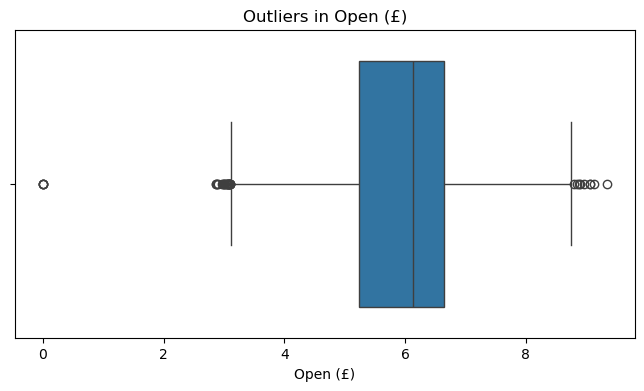

```python
# Box plot for Open (£)
plt.figure(figsize=(8,4))
sns.boxplot(x = df['Open (£)'])
plt.title("Outliers in Open (£)")
plt.xlabel("Open (£)")
plt.show()
```

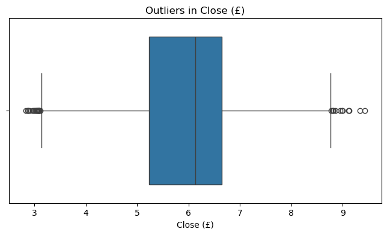

```python
# Box plot for Close (£)
plt.figure(figsize=(8,4))
sns.boxplot(x = df['Close (£)'])
plt.title("Outliers in Close (£)")
plt.xlabel("Close (£)")
plt.show()
```

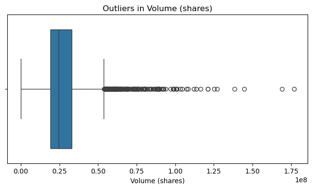

```python
# Box plot for Volume (shares)
plt.figure(figsize=(8,4))
sns.boxplot(x = df['Volume (shares)'])
plt.title("Outliers in Volume (shares)")
plt.xlabel("Volume (shares)")
plt.show()
```

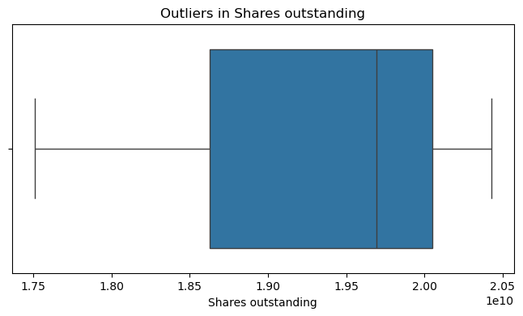

```python
# Box plot for Shares outstanding
plt.figure(figsize=(8,4))
sns.boxplot(x = df['Shares outstanding'])
plt.title("Outliers in Shares outstanding")
plt.xlabel("Shares outstanding")
plt.show()
```

```python
# Function to remove outlier
def remove_outliers(df, feature):
    Q1 = df[feature].quantile(0.25)
    Q3 = df[feature].quantile(0.75)
    IQR = Q3 - Q1
    lower_bound = Q1 - 1.5*IQR
    upper_bound = Q3 + 1.5*IQR
    return df[(df[feature] >= lower_bound) & (df[feature] <= upper_bound)].reset_index().set_index('Date')

# Remove Outliers from amount
df = remove_outliers(df, "Open (£)")
df = remove_outliers(df, "High (£)")
df = remove_outliers(df, "Low (£)")
df = remove_outliers(df, "Close (£)")
df = remove_outliers(df, "Volume (shares)")
```

### c. Feature Engineering

```python
# Price Based Features
df['Volatility'] = df['High (£)'] - df['Low (£)']
df['Volatility'] = df['Volatility'].rolling(window=30).mean()

df['Daily_Return'] = ((df['Close (£)'] - df['Open (£)'])/df['Open (£)']) * 100
df['Daily_Return'] = df['Daily_Return'].rolling(window=30).mean()

df['MA_30'] = df['Close (£)'].rolling(window=30).mean()
df['MA_90'] = df['Close (£)'].rolling(window=90).mean()

df.head()
```

| Date | Open (£) | High (£) | Low (£) | Close (£) | Volume (shares) | Shares outstanding | Market cap (m £) | Volatility | Daily_Return | MA_30 | MA_90 |
| --- | --- | --- | --- | --- | --- | --- | --- | --- | --- | --- | --- |
| 2010-05-28 | 6.385 | 6.400 | 6.270 | 6.278 | 35776668 | 17509647048 | 109925.562030 | NaN | NaN | NaN | NaN |
| 2010-06-01 | 6.222 | 6.355 | 6.222 | 6.355 | 50609420 | 17509647048 | 111273.807324 | NaN | NaN | NaN | NaN |
| 2010-06-02 | 6.260 | 6.339 | 6.220 | 6.338 | 23121252 | 17509647048 | 110976.139851 | NaN | NaN | NaN | NaN |
| 2010-06-03 | 6.370 | 6.449 | 6.348 | 6.394 | 26304218 | 17509647048 | 111956.684160 | NaN | NaN | NaN | NaN |
| 2010-06-04 | 6.381 | 6.448 | 6.234 | 6.301 | 33183286 | 17509647048 | 110328.279771 | NaN | NaN | NaN | NaN |

```python
# Volume Related Features

df['Volume Changes %'] = (df['Volume (shares)'] - df['Volume (shares)'].shift(1)) / df['Volume (shares)'].shift(1)
df['Volume Changes %'] = df['Volume Changes %'].rolling(window=30).mean()

df['MA_Volume'] = df['Volume (shares)'].rolling(window=30).mean()

df.head()
```

| Date | Open (£) | High (£) | Low (£) | Close (£) | Volume (shares) | Shares outstanding | Market cap (m £) | Volatility | Daily_Return | MA_30 | MA_90 | Volume Changes % | MA_Volume |
| --- | --- | --- | --- | --- | --- | --- | --- | --- | --- | --- | --- | --- | --- |
| 2010-05-28 | 6.385 | 6.400 | 6.270 | 6.278 | 35776668 | 17509647048 | 109925.562030 | NaN | NaN | NaN | NaN | NaN | NaN |
| 2010-06-01 | 6.222 | 6.355 | 6.222 | 6.355 | 50609420 | 17509647048 | 111273.807324 | NaN | NaN | NaN | NaN | NaN | NaN |
| 2010-06-02 | 6.260 | 6.339 | 6.220 | 6.338 | 23121252 | 17509647048 | 110976.139851 | NaN | NaN | NaN | NaN | NaN | NaN |
| 2010-06-03 | 6.370 | 6.449 | 6.348 | 6.394 | 26304218 | 17509647048 | 111956.684160 | NaN | NaN | NaN | NaN | NaN | NaN |
| 2010-06-04 | 6.381 | 6.448 | 6.234 | 6.301 | 33183286 | 17509647048 | 110328.279771 | NaN | NaN | NaN | NaN | NaN | NaN |

```python
# Checking for null values
df.isnull().sum()
```

```
Open (£)               0
High (£)               0
Low (£)                0
Close (£)              0
Volume (shares)        0
Shares outstanding     0
Market cap (m £)       0
Volatility            29
Daily_Return          29
MA_30                 29
MA_90                 89
Volume Changes %      60
MA_Volume             29
dtype: int64
```

```python
# Fill the null values by backward fill
df.fillna(method='bfill', inplace=True)
```

## 3. EDA

### a. HSBC Closing Price Trend (2010-2025)

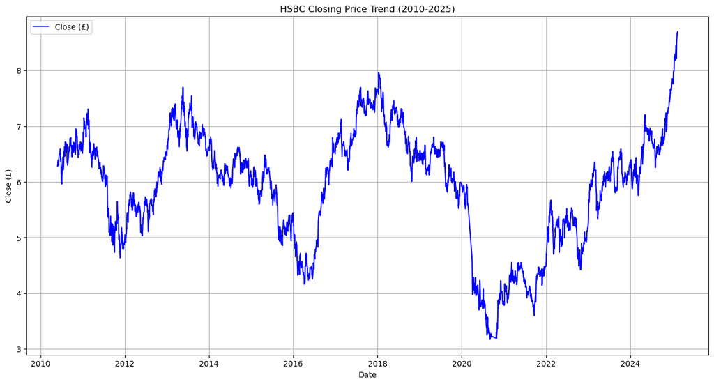

```python
# HSBC Closing Price Trend (2010-2025)
plt.figure(figsize=(16, 8))
plt.plot(df.index, df['Close (£)'], color='b', label='Close (£)')

plt.title('HSBC Closing Price Trend (2010-2025)')
plt.xlabel('Date')
plt.ylabel('Close (£)')

plt.grid(True)
plt.legend()
plt.show()
```

### b. HSBC Stock Price and Trading Volume Trends (2010-2025): A 30-Day Moving Average Analysis

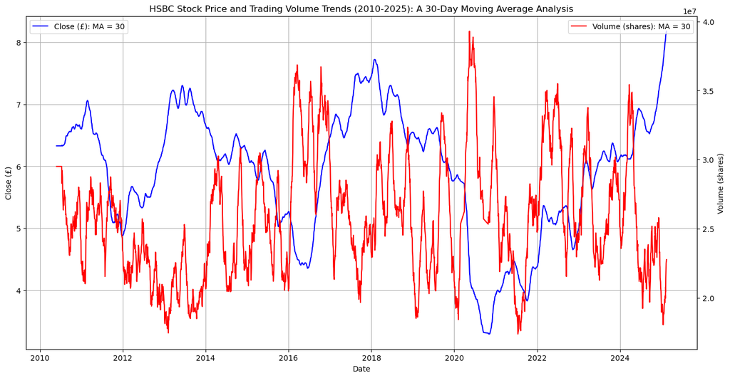

```python
# HSBC Stock Price and Trading Volume Trends (2010-2025): A 30-Day Moving Average Analysist
fig, ax1 = plt.subplots(figsize=(16, 8))

ax1.plot(df.index, df['MA_30'], color='b', label='Close (£): MA = 30')
ax1.set_ylabel('Close (£)')

ax2 = ax1.twinx()
ax2.plot(df.index, df['MA_Volume'], color='r', label='Volume (shares): MA = 30')
ax2.set_ylabel('Volume (shares)')

plt.title('HSBC Stock Price and Trading Volume Trends (2010-2025): A 30-Day Moving Average Analysis')
ax1.set_xlabel('Date')
ax1.grid(True)
ax1.legend()
ax2.legend()

plt.show()
```

### c. HSBC Stock Daily Returns (2010-2025) with 30-Day Moving Average

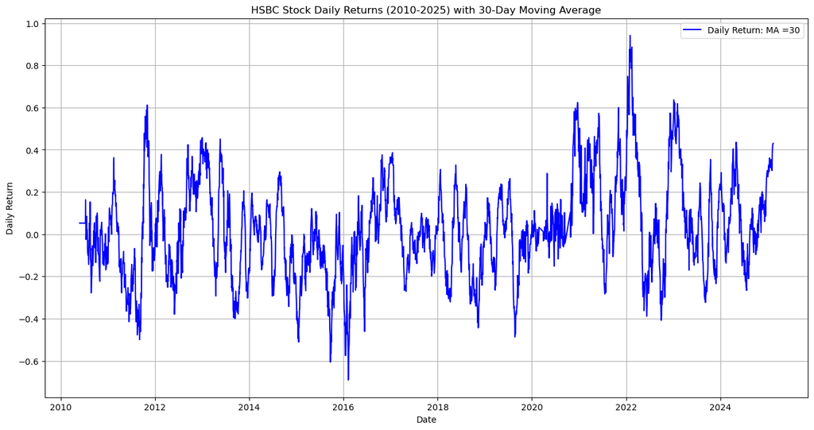

```python
# HSBC Stock Daily Returns (2010-2025) with 30-Day Moving Average
plt.figure(figsize=(16, 8))
plt.plot(df.index, df['Daily_Return'], color='b',label='Daily Return: MA =30')

plt.title('HSBC Stock Daily Returns (2010-2025) with 30-Day Moving Average')
plt.xlabel('Date')
plt.ylabel('Daily Return')

plt.grid(True)
plt.legend()
plt.show()
```

### d. HSBC Stock Volatility (2010-2025) with 30-Day Moving Average)

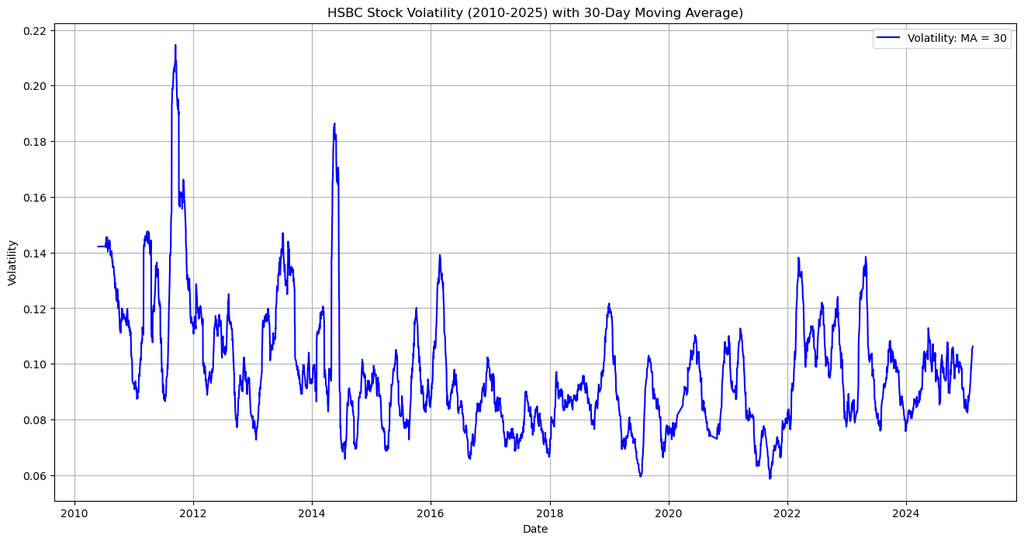

```python
# HSBC Stock Volatility (2010-2025) with 30-Day Moving Average)
plt.figure(figsize=(16, 8))
plt.plot(df.index, df['Volatility'], color='b',label='Volatility: MA = 30')

plt.title('HSBC Stock Volatility (2010-2025) with 30-Day Moving Average)')
plt.xlabel('Date')
plt.ylabel('Volatility')

plt.grid(True)
plt.legend()
plt.show()
```

### e. HSBC Stock Monthly Closing Price Trends (2010-2025)

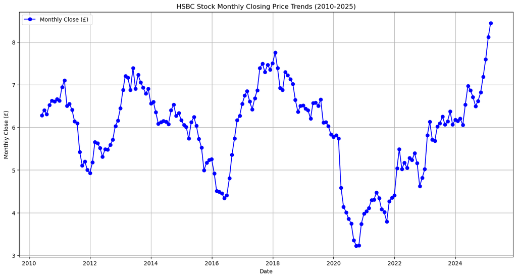

```python
# HSBC Stock Monthly Closing Price Trends (2010-2025)
monthly_avg = df.resample('M')['Close (£)'].mean()

plt.figure(figsize=(16, 8))
plt.plot(monthly_avg.index, monthly_avg, marker='o', linestyle='-', color='b',label='Monthly Close (£) ')

plt.title('HSBC Stock Monthly Closing Price Trends (2010-2025)')
plt.xlabel('Date')
plt.ylabel('Monthly Close (£)')

plt.grid(True)
plt.legend()
plt.show()
```

### f. Correlation Heatmap

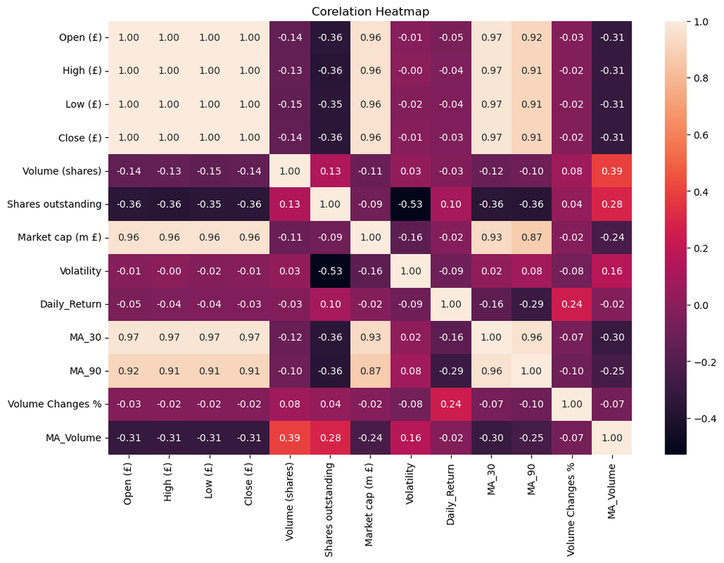

```python
# Corelation Heatmap
correlation = df.corr(numeric_only=True)

plt.figure(figsize=(12,8))
sns.heatmap(correlation, annot=True, fmt=".2f")
plt.title("Corelation Heatmap")
plt.show()
```

## 4. Data Preparation

### a. Train Test Split

```python
# Selecting relevant features for modeling
X = [ "Market cap (m £)", "MA_90", "Volatility", "Daily_Return", "Volume Changes %", "MA_Volume"]
y = "Close (£)"

# Splitting into training and testing sets (80% train, 20% test)
train_size = int(len(df) * 0.8)
train_data, test_data = df.iloc[:train_size], df.iloc[train_size:]

# Splitting features and target
X_train, y_train = train_data[X], train_data[y]
X_test, y_test = test_data[X], test_data[y]

# Display dataset sizes
X_train.shape, X_test.shape
```

```
((2770, 6), (693, 6))
```

### b. Scaling

```python
# Apply StandarScaler
scaler = StandardScaler()
X_train = scaler.fit_transform(X_train)
X_test = scaler.transform(X_test)
```

## 5. Model Development & Evaluation

### a. ARIMA Model

```python
# List for evaluation of all models
evaluation_metrics = []

# Fit Auto-ARIMA model on training data
arima_model = auto_arima(
    y_train,
    seasonal=True,  # No explicit seasonality
    stepwise=True,
    suppress_warnings=True,
    trace=True
)
order = arima_model.order

# Summary of the selected ARIMA model
arima_model.summary()
```

```
Performing stepwise search to minimize aic
 ARIMA(2,1,2)(0,0,0)[0] intercept   : AIC=-5995.535, Time=1.44 sec
 ARIMA(0,1,0)(0,0,0)[0] intercept   : AIC=-6000.839, Time=0.17 sec
 ARIMA(1,1,0)(0,0,0)[0] intercept   : AIC=-5999.573, Time=0.21 sec
 ARIMA(0,1,1)(0,0,0)[0] intercept   : AIC=-5999.566, Time=0.89 sec
 ARIMA(0,1,0)(0,0,0)[0]             : AIC=-6002.775, Time=0.12 sec
 ARIMA(1,1,1)(0,0,0)[0] intercept   : AIC=-5997.503, Time=0.36 sec

Best model:  ARIMA(0,1,0)(0,0,0)[0]
Total fit time: 3.183 seconds
```

SARIMAX Results

| Dep. Variable: | y | No. Observations: | 2770 |
| --- | --- | --- | --- |
| Model: | SARIMAX(0, 1, 0) | Log Likelihood | 3002.388 |
| Date: | Fri, 21 Mar 2025 | AIC | -6002.775 |
| Time: | 16:25:32 | BIC | -5996.849 |
| Sample: | 0 | HQIC | -6000.635 |
|  | - 2770 |  |  |
| Covariance Type: | opg |  |  |

|  | coef | std err | z | P>\|z\| | [0.025 | 0.975] |
| --- | --- | --- | --- | --- | --- | --- |
| sigma2 | 0.0067 | 7.69e-05 | 87.022 | 0.000 | 0.007 | 0.007 |

| Ljung-Box (L1) (Q): | 0.73 | Jarque-Bera (JB): | 9418.31 |
| --- | --- | --- | --- |
| Prob(Q): | 0.39 | Prob(JB): | 0.00 |
| Heteroskedasticity (H): | 1.00 | Skew: | -0.71 |
| Prob(H) (two-sided): | 0.94 | Kurtosis: | 11.92 |

Warnings:  
[1] Covariance matrix calculated using the outer product of gradients (complex-step).

```python
# Apply ARIMA model
arima_model = ARIMA(y_train, order=order)
arima_fitted = arima_model.fit()
arima_forecast = arima_fitted.forecast(steps=len(y_test))

# Model Evaluation for ARIMA
arima_rmse = np.sqrt(mean_squared_error(y_test, arima_forecast))
arima_mae = mean_absolute_error(y_test, arima_forecast)
arima_r2 = r2_score(y_test, arima_forecast)
evaluation_metrics.append(["ARIMA", arima_rmse, arima_mae, arima_r2])

# Print the evaluation results for ARIMA
print(f"ARIMA RMSE: {arima_rmse:.2f}")
print(f"ARIMA MAE: {arima_mae:.2f}")
print(f"ARIMA R² Score: {arima_r2:.2f}")
```

```
ARIMA RMSE: 1.21
ARIMA MAE: 0.96
ARIMA R² Score: -1.02
```

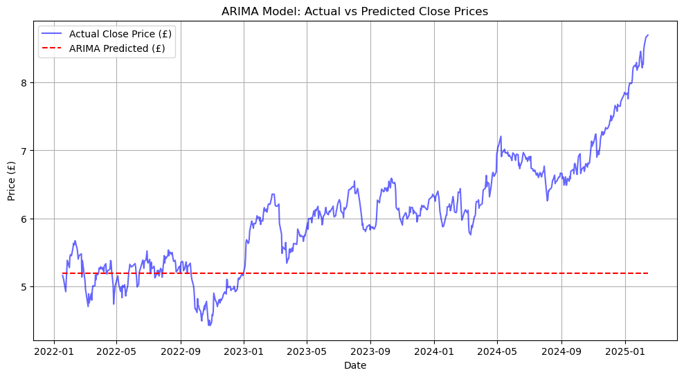

```python
# Plot actual vs predicted values from ARIMA
plt.figure(figsize=(12, 6))
plt.plot(y_test.index, y_test, label="Actual Close Price (£)", color="blue", alpha=0.6)
plt.plot(y_test.index, arima_forecast, label="ARIMA Predicted (£)", color="red", linestyle="dashed")
plt.xlabel("Date")
plt.ylabel("Price (£)")
plt.title("ARIMA Model: Actual vs Predicted Close Prices")
plt.legend()
plt.grid(True)
plt.show()
```

### b. Linear Regression

```python
# Apply Linear Regression Model
lr_model = LinearRegression()
lr_model.fit(X_train, y_train)
lr_pred = lr_model.predict(X_test)

# Model Evaluation for Linear Regression
lr_rmse = np.sqrt(mean_squared_error(y_test, lr_pred))
lr_mae = mean_absolute_error(y_test, lr_pred)
lr_r2 = r2_score(y_test, lr_pred)
evaluation_metrics.append(["Linear Regression", lr_rmse, lr_mae, lr_r2])

# Print the evaluation results for Linear Regression
print(f"Linear Regression RMSE: {lr_rmse:.2f}")
print(f"Linear Regression MAE: {lr_mae:.2f}")
print(f"Linear Regression R² Score: {lr_r2:.2f}")
```

```
Linear Regression RMSE: 0.21
Linear Regression MAE: 0.17
Linear Regression R² Score: 0.94
```

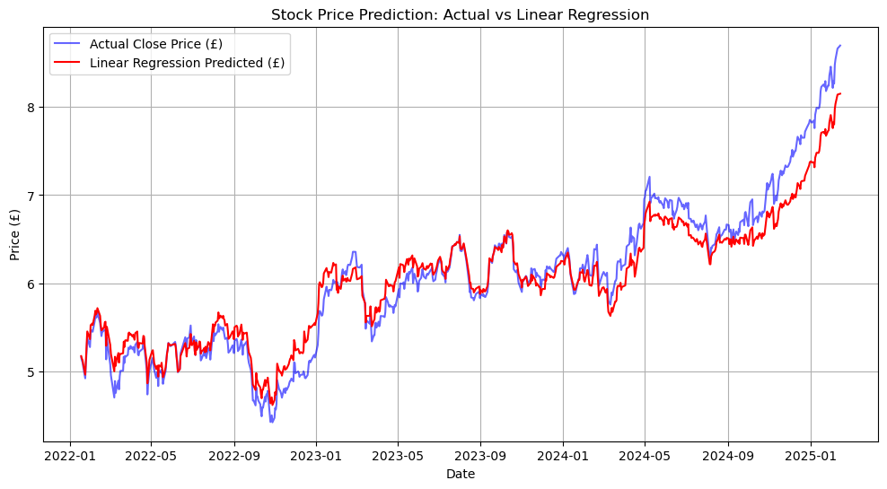

```python
# Plot actual vs predicted values from Linear Regression
plt.figure(figsize=(12, 6))
plt.plot(y_test.index, y_test, label="Actual Close Price (£)", color="blue", alpha=0.6)
plt.plot(y_test.index, lr_pred, label="Linear Regression Predicted (£)", color="red")
plt.xlabel("Date")
plt.ylabel("Price (£)")
plt.title("Stock Price Prediction: Actual vs Linear Regression")
plt.legend()
plt.grid(True)
plt.show()
```

### c. Support Vector Machine

```python
# Apply SVR Model
svr_model = SVR(kernel='rbf')
svr_model.fit(X_train, y_train)
svr_pred = svr_model.predict(X_test)

# Model Evaluation for SVR
svr_rmse = np.sqrt(mean_squared_error(y_test, svr_pred))
svr_mae = mean_absolute_error(y_test, svr_pred)
svr_r2 = r2_score(y_test, svr_pred)
evaluation_metrics.append(["SVR", svr_rmse, svr_mae, svr_r2])

# Print the evaluation results for SVR
print(f"SVR RMSE: {svr_rmse:.2f}")
print(f"SVR MAE: {svr_mae:.2f}")
print(f"SVR R² Score: {svr_r2:.2f}")
```

```
SVR RMSE: 0.30
SVR MAE: 0.22
SVR R² Score: 0.87
```

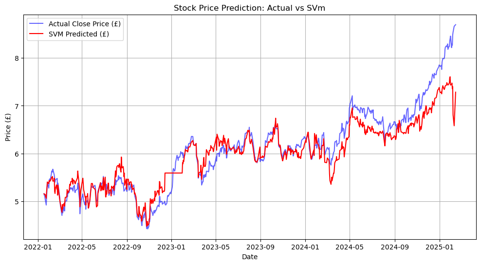

```python
# Plot actual vs predicted values from SVR
plt.figure(figsize=(12, 6))
plt.plot(y_test.index, y_test, label="Actual Close Price (£)", color="blue", alpha=0.6)
plt.plot(y_test.index, svr_pred, label="SVM Predicted (£)", color="red")
plt.xlabel("Date")
plt.ylabel("Price (£)")
plt.title("Stock Price Prediction: Actual vs SVm")
plt.legend()
plt.grid(True)
plt.show()
```

### d. Random Forest

```python
# Apply Random Forest Model
rf_model = RandomForestRegressor(random_state=42)
rf_model.fit(X_train, y_train)
rf_pred = rf_model.predict(X_test)

# Model Evaluation for Random Forest
rf_rmse = np.sqrt(mean_squared_error(y_test, rf_pred))
rf_mae = mean_absolute_error(y_test, rf_pred)
rf_r2 = r2_score(y_test, rf_pred)
evaluation_metrics.append(["Random Forest", rf_rmse, rf_mae, rf_r2])

# Print the evaluation results for Random Forest
print(f"Random Forest RMSE: {rf_rmse:.2f}")
print(f"Random Forest MAE: {rf_mae:.2f}")
print(f"Random Forest R² Score: {rf_r2:.2f}")
```

```
Random Forest RMSE: 0.31
Random Forest MAE: 0.24
Random Forest R² Score: 0.86
```

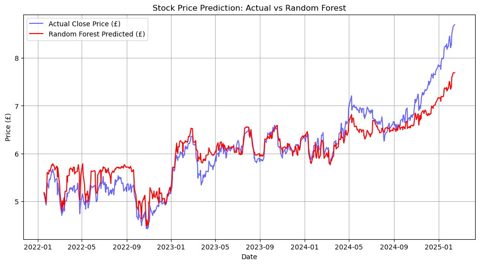

```python
# Plot actual vs predicted values from Random Forest
plt.figure(figsize=(12, 6))
plt.plot(y_test.index, y_test, label="Actual Close Price (£)", color="blue", alpha=0.6)
plt.plot(y_test.index, rf_pred, label="Random Forest Predicted (£)", color="red")
plt.xlabel("Date")
plt.ylabel("Price (£)")
plt.title("Stock Price Prediction: Actual vs Random Forest")
plt.legend()
plt.grid(True)
plt.show()
```

### e. XGBoost

```python
# Apply XGBoost Model
xgb_model = XGBRegressor(random_state=42)
xgb_model.fit(X_train, y_train)
xgb_pred = xgb_model.predict(X_test)

# Model Evaluation for XGBoost
xgb_rmse = np.sqrt(mean_squared_error(y_test, xgb_pred))
xgb_mae = mean_absolute_error(y_test,xgb_pred)
xgb_r2 = r2_score(y_test, xgb_pred)
evaluation_metrics.append(["XGBoost", xgb_rmse, xgb_mae, xgb_r2])

# Print the evaluation results for XGBoost
print(f"XGBoost RMSE: {xgb_rmse:.2f}")
print(f"XGBoost MAE: {xgb_mae:.2f}")
print(f"XGBoost R² Score: {xgb_r2:.2f}")
```

```
XGBoost RMSE: 0.33
XGBoost MAE: 0.26
XGBoost R² Score: 0.85
```

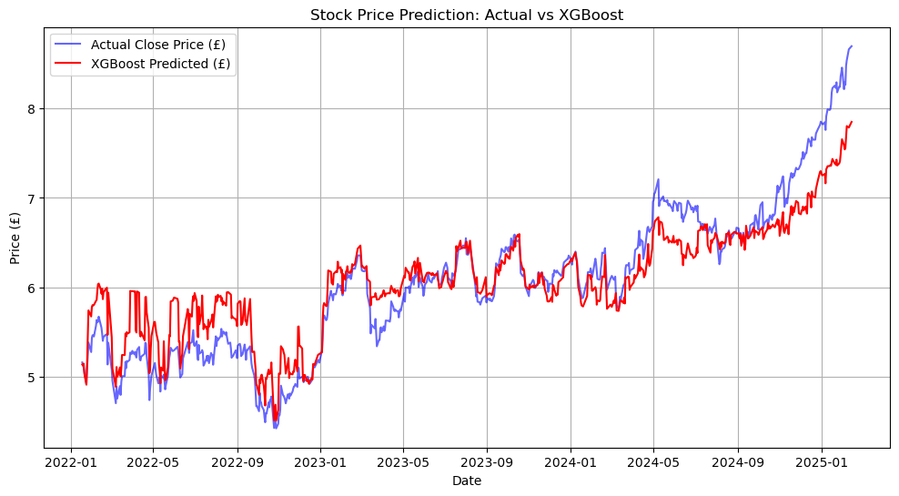

```python
# Plot actual vs predicted values from XGBoost
plt.figure(figsize=(12, 6))
plt.plot(y_test.index, y_test, label="Actual Close Price (£)", color="blue", alpha=0.6)
plt.plot(y_test.index, xgb_pred, label="XGBoost Predicted (£)", color="red")
plt.xlabel("Date")
plt.ylabel("Price (£)")
plt.title("Stock Price Prediction: Actual vs XGBoost")
plt.legend()
plt.grid(True)
plt.show()
```

## 6. Result

```python
# Evaluation DataFrame
evaluation_df = pd.DataFrame(evaluation_metrics, columns=['Model', 'RMSE', 'MAE', 'R² Score'])
evaluation_df.set_index("Model", inplace=True)
evaluation_df
```

| Model | RMSE | MAE | R² Score |
| --- | --- | --- | --- |
| ARIMA | 1.209153 | 0.956576 | -1.022935 |
| Linear Regression | 0.214930 | 0.171223 | 0.936083 |
| SVR | 0.301006 | 0.219992 | 0.874637 |
| Random Forest | 0.312913 | 0.240879 | 0.864523 |
| XGBoost | 0.326111 | 0.256868 | 0.852854 |

- The Linear Regression model is the best-performing model based on the evaluation metrics. It has the lowest RMSE (0.2149) and MAE (0.1712), indicating minimal error. Additionally, it has the highest R² score (0.9361), meaning it explains 93.6% of the variance in the data.

**Why Other Models Are Not Good:**

- **ARIMA**: This model is designed for time series forecasting, but it struggles with datasets where relationships between features are better captured by regression models. The high RMSE (1.2091) and negative R² (-1.0229) indicate poor performance, likely due to ARIMA's inability to handle complex feature dependencies effectively.
- **SVR**: Although it performs better than ARIMA, its higher RMSE (0.3010) and lower R² (0.8746) suggest that it does not capture the full variability of the data as effectively as Linear Regression.
- **Random Forest**: While it performs well, Random Forest is prone to overfitting, especially with small or noisy datasets. The RMSE (0.3129) and R² (0.8645) indicate that it is slightly less precise compared to Linear Regression.
- **XGBoost**: Although XGBoost is a powerful boosting algorithm, it has the highest RMSE among the ML models (0.3261). This suggests it may be overfitting or not generalizing well, possibly due to a lack of hyperparameter tuning.